# ERU Project - data cleaning & exploratory analysis

Joy Wu

16 August 2015

# Introduction:

ERU stands for Extended Recovery Unit; a ‘23-hour’ unit. This is a new admission category for patients who need a slightly longer overnight monitoring period post-operative but do not necessarily need to be admitted for over 24 hours. However, since the introduction of ERU admissions, the rate of actual ‘on-time’ discharges have been low.

# Objectives of this study are:

1. To find out the various reasons why ERU patients were discharged late or admitted inpatient on post-operative day one.
2. Come up with a pre-operative prediction model to better assess whether a patient is likely able to be discharged on time.

# Method:

- Data source: Partner’s LMR database and nursing log on ERU
- Pre-op co-morbidities, various functional scores in pre-op nursing assessment form, OR service and payor information, summary of progress notes throughout PACU and ERU stay, as well as outpatient notes available on LMR are reviewed.
- The main outcome is whether the patient is discharged on time, late or admitted inpatient
- Secondary outcomes include:
1. late minute foley placement on POD1
2. Re-admission or ED visit within 3 days of discharge
3. Patient stating not ready for discharge when phone followed up at 2 days.

# Pre-lim Results:

# Data cleaning and rough analysis:

The analysis is done in R. Aim to do some logistic regression eventually. Currently still waiting to clean up co-morbidity data first but here’s what we have so far:

## Overral structure of the raw ERU dataset:

```r
str(eru)
```

```
## 'data.frame':    281 obs. of  35 variables:
##  $ ID                        : int  1 2 3 4 5 6 7 8 9 10 ...
##  $ ERU_outcome               : Factor w/ 3 levels "0","1","IP": 3 3 3 3 3 3 3 3 3 3 ...
##  $ Age                       : int  68 72 49 57 22 27 63 76 68 67 ...
##  $ Gender                    : Factor w/ 3 levels "F","F ","M": 3 1 3 3 1 1 1 3 3 3 ...
##  $ Race                      : Factor w/ 9 levels "Arab","Asian",..: 8 8 4 8 8 4 8 8 8 8 ...
##  $ Married                   : Factor w/ 3 levels "0","1","NULL": 2 2 2 2 1 1 1 2 2 1 ...
##  $ no_English                : int  0 0 1 0 0 0 0 0 0 0 ...
##  $ employment_status         : Factor w/ 4 levels "0","1","2","NULL": 2 2 3 1 1 1 3 2 1 2 ...
##  $ education                 : Factor w/ 4 levels "0","1","2","NULL": 3 1 2 2 1 1 1 2 3 1 ...
##  $ blind_HOH                 : int  0 0 0 0 0 0 0 1 0 0 ...
##  $ alone_postop              : Factor w/ 3 levels "0","1","NULL": 1 1 1 1 1 1 1 1 1 1 ...
##  $ chronic_pain              : Factor w/ 3 levels "0","1","NULL": 1 2 1 1 1 1 2 1 2 2 ...
##  $ O2_CPAP_home              : int  0 0 0 1 0 0 0 0 0 0 ...
##  $ MorseFall_risk            : Factor w/ 17 levels "0","15","20",..: 6 10 17 6 1 8 14 6 9 11 ...
```

[output cut: 21 more lines]

## Rough summary of ERU outcome: On_time, Late, or IP (admitted inpatient)

```r
# Number of patients in each category
summary(eru$ERU_outcome)
```

```
## On_time    Late      IP
##     104     140      37
```

```r
# Proportion of patients in each category
prop.table(table(eru$ERU_outcome))
```

```
##
##   On_time      Late        IP
## 0.3701068 0.4982206 0.1316726
```

```r
paste(round(prop.table(table(eru$ERU_outcome))*100,2), "%")
```

```
## [1] "37.01 %" "49.82 %" "13.17 %"
```

## Demographics, education, employment split by ERU outcome

```r
# Age, gender, marital status, smoking status and langauge
demographics <- data.frame(t(demo.brkdown), t(demo.overall)); demographics
```

```
##                                      X1                          X2
## ERU_outcome                     On_time                        Late
## Age                55.54 [52.44-58.64%]        57.97 [55.27-60.67%]
## Female      82 (78.85%) [70.04%-85.59%]     91 (65%) [56.79%-72.4%]
## Married     65 (64.36%) [52.42%-71.64%] 82 (58.99%) [49.93%-66.73%]
## Smoker         9 (8.74%) [4.56%-15.74%]   12 (8.57%) [4.97%-14.38%]
## No_English      4 (3.85%) [1.51%-9.47%]   10 (7.14%) [3.93%-12.65%]
##                                      X3              t.demo.overall.
## ERU_outcome                          IP                      Overall
## Age                60.16 [54.12-66.21%]         57.36 [55.44-59.28%]
## Female      21 (56.76%) [40.91%-71.33%] 194 (69.04%) [63.41%-74.16%]
## Married     17 (45.95%) [31.04%-61.62%] 164 (59.21%) [52.35%-64.15%]
## Smoker           2 (5.41%) [1.5%-17.7%]    23 (8.21%) [5.49%-12.02%]
## No_English       2 (5.41%) [1.5%-17.7%]     16 (5.69%) [3.53%-9.05%]
```

```r
# Race and missing information
Race <- data.frame(t(race.brkdown), t(race.overall)); Race
```

```
##                                      X1                           X2
## ERU_outcome                     On_time                         Late
## White       71 (72.45%) [58.31%-76.86%] 103 (75.18%) [65.33%-80.49%]
## Black        16 (16.33%) [9.32%-24.08%]    12 (8.76%) [4.83%-14.61%]
## Hispanic       9 (9.18%) [4.28%-16.22%]    13 (9.49%) [5.35%-15.48%]
## Other           2 (2.04%) [0.48%-6.92%]     9 (6.57%) [3.32%-11.94%]
##                                      X3              t.race.overall.
## ERU_outcome                          IP                      Overall
## White       28 (75.68%) [59.88%-86.64%] 202 (74.26%) [66.18%-76.99%]
## Black         5 (13.51%) [5.91%-27.98%]   33 (12.13%) [8.33%-16.23%]
## Hispanic         3 (8.11%) [2.8%-21.3%]    25 (9.19%) [5.95%-13.01%]
## Other           1 (2.7%) [0.48%-13.82%]     12 (4.41%) [2.36%-7.49%]
```

```r
# Education and missing information
education <- data.frame(t(edu.brkdown), t(edu.overall)); education
```

```
##                                         X1                          X2
## ERU_outcome                        On_time                        Late
## Grade8_or_less     2 (2.25%) [0.39%-7.22%]     2 (1.75%) [0.26%-5.55%]
## High_school     25 (28.09%) [16.44%-33.6%] 33 (28.95%) [16.99%-31.63%]
## College_plus   62 (69.66%) [49.53%-68.99%]    79 (69.3%) [47.8%-64.7%]
##                                         X3              t.edu.overall.
## ERU_outcome                             IP                     Overall
## Grade8_or_less    2 (5.71%) [1.36%-18.13%]     6 (2.52%) [0.87%-4.82%]
## High_school     9 (25.71%) [12.37%-41.56%] 67 (28.15%) [19.07%-29.35%]
## College_plus   24 (68.57%) [47.42%-79.28%] 165 (69.33%) [52.7%-64.49%]
```

```r
# Employment status and missing information
employment <- data.frame(t(employ.brkdown), t(employ.overall)); employment
```

```
##                                      X1                          X2
## ERU_outcome                     On_time                        Late
## Employed    56 (58.33%) [43.83%-63.58%] 64 (46.38%) [37.34%-54.32%]
## Retired        24 (25%) [15.62%-32.56%] 41 (29.71%) [22.06%-37.67%]
## Unemployed   16 (16.67%) [9.32%-24.08%] 33 (23.91%) [17.01%-31.62%]
##                                      X3            t.employ.overall.
## ERU_outcome                          IP                      Overall
## Employed    17 (45.95%) [31.04%-61.62%] 137 (50.55%) [42.79%-54.75%]
## Retired     15 (40.54%) [26.35%-56.51%]  80 (29.52%) [23.35%-34.19%]
## Unemployed    5 (13.51%) [5.91%-27.98%]  54 (19.93%) [14.88%-24.42%]
```

```r
# Missing information
Missing_demo_info
```

```
##                     V1      V2     V3
## ERU_outcome    On_time    Late     IP
## Age                0 %     0 %    0 %
## Gender             0 %     0 %    0 %
## Marital_status  2.88 %  0.71 %    0 %
## Smoking_status  0.96 %     0 %    0 %
## no_English         0 %     0 %    0 %
## Race            5.77 %  2.14 %    0 %
## Education      14.42 % 18.57 % 5.41 %
## Employment      7.69 %  1.43 %    0 %
```

## Functional baseline split by ERU outcome

```r
# Overall functional baseline of all patients
func_baseline_overall
```

```
##                      proportion n_length   n missing_value
## blind_HOH               12.1  %      281  34             0
## alone_postop           11.07  %      281  30            10
## chronic_pain           33.95  %      281  92            10
## O2_CPAP_home            7.83  %      281  22             0
## MorseFallrisk_45plus   14.29  %      281  40             1
## mob_aid                20.28  %      281  57             0
## METS_less4             17.55  %      281  43            36
## BMI_over30             36.07  %      281 101             1
## ASA_34                 53.05  %      281 148             2
```

```r
# Functional baseline of patients who went home on time
func_ontime
```

```
##                      proportion n_length  n missing_value
## blind_HOH               12.5  %      104 13             0
## alone_postop            6.06  %      104  6             5
## chronic_pain           33.66  %      104 34             3
## O2_CPAP_home            8.65  %      104  9             0
## MorseFallrisk_45plus    7.69  %      104  8             0
## mob_aid                13.46  %      104 14             0
## METS_less4             15.05  %      104 14            11
## BMI_over30             41.35  %      104 43             0
## ASA_34                 45.63  %      104 47             1
```

```r
# Functional baseline of patients who went home late
func_late
```

```
##                      proportion n_length  n missing_value
## blind_HOH              11.43  %      140 16             0
## alone_postop           13.24  %      140 18             4
## chronic_pain           30.08  %      140 40             7
## O2_CPAP_home            6.43  %      140  9             0
## MorseFallrisk_45plus   13.57  %      140 19             0
## mob_aid                   20  %      140 28             0
## METS_less4             17.74  %      140 22            16
## BMI_over30             32.37  %      140 45             1
## ASA_34                 53.24  %      140 74             1
```

```r
# Functional baseline of patients who were admitted inpatient
func_IP
```

```
##                      proportion n_length  n missing_value
## blind_HOH              13.51  %       37  5             0
## alone_postop           16.67  %       37  6             1
## chronic_pain           48.65  %       37 18             0
## O2_CPAP_home           10.81  %       37  4             0
## MorseFallrisk_45plus   36.11  %       37 13             1
## mob_aid                40.54  %       37 15             0
## METS_less4                25  %       37  7             9
## BMI_over30             35.14  %       37 13             0
## ASA_34                 72.97  %       37 27             0
```

## OR service, payer and day of week:

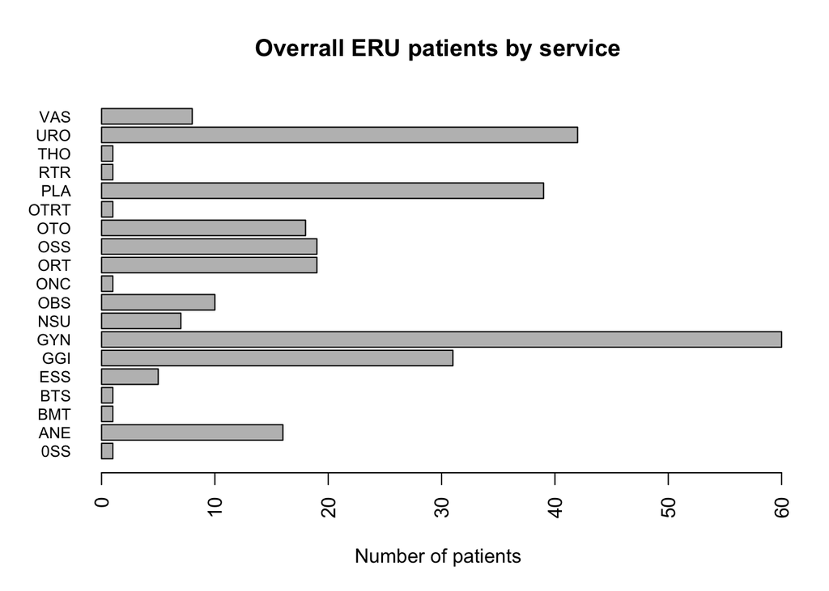

```r
# Service barplot overall
par(las=2)
par(mar=c(5,4,4,2))
barplot(table(ORinfo$service), horiz = TRUE, cex.names=0.8)
title(main = "Overrall ERU patients by service", xlab = "Number of patients")
```

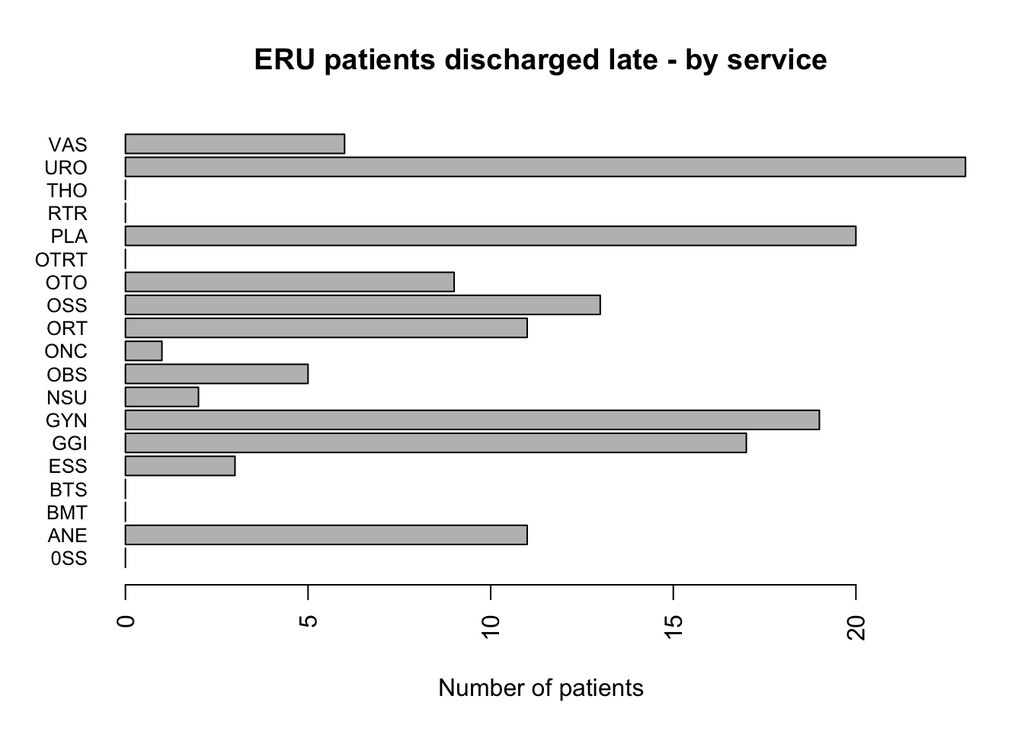

```r
# Service barplot: Late patients
barplot(table(days_late$service), horiz = TRUE, cex.names=0.8)
title(main = "ERU patients discharged late - by service", xlab = "Number of patients")
```

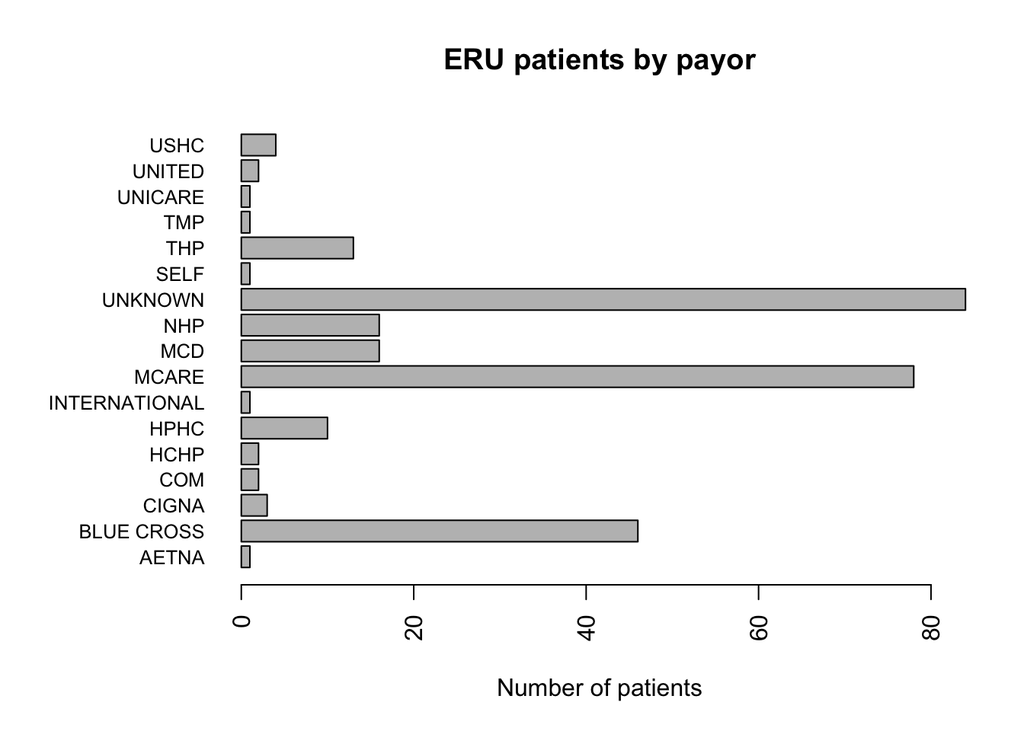

```r
# Table of late and admitted patients by service
service <- NULL
n_total <- NULL
n_late <- NULL
percent_late <- NULL
n_admitedIP <- NULL
percent_IP <- NULL
for(i in 1:length(levels(ORinfo$service))){
  service[i] <- levels(ORinfo$service)[i]
  n_total[i] <- nrow(ORinfo[ORinfo$service == levels(ORinfo$service)[i],])
  n_late[i] <- nrow(ORinfo[ORinfo$service == levels(ORinfo$service)[i] & ORinfo$ERU_outcome == "Late",])
  percent_late[i] <- paste(round(n_late[i]/n_total[i]*100, 0), "%")
  n_admitedIP[i] <- nrow(ORinfo[ORinfo$service == levels(ORinfo$service)[i] & ORinfo$ERU_outcome == "IP",])
  percent_IP[i] <- paste(round(n_admitedIP[i]/n_total[i]*100, 0), "%")
}
late_prop_service <- data.frame(service, n_total, n_late, percent_late, n_admitedIP, percent_IP)


# Payer barplot overrall
par(mar=c(5,8,4,2))
barplot(table(ORinfo$payer), horiz = TRUE, cex.names=0.8)
title(main = "ERU patients by payor", xlab = "Number of patients")
```

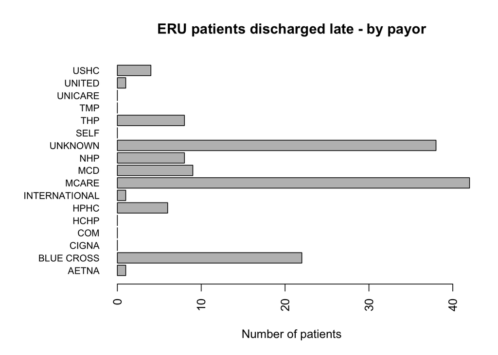

```r
# Payer barplot: Late patients
barplot(table(days_late$payer), horiz = TRUE, cex.names=0.8)
title(main = "ERU patients discharged late - by payor", xlab = "Number of patients")
```

```r
# Table of late and admitted patients by payer
payer <- NULL
n_total <- NULL
n_late <- NULL
percent_late <- NULL
n_admitedIP <- NULL
percent_IP <- NULL
for(i in 1:length(levels(ORinfo$payer))){
  payer[i] <- levels(ORinfo$payer)[i]
  n_total[i] <- nrow(ORinfo[ORinfo$payer == levels(ORinfo$payer)[i],])
  n_late[i] <- nrow(ORinfo[ORinfo$payer == levels(ORinfo$payer)[i] & ORinfo$ERU_outcome == "Late",])
  percent_late[i] <- paste(round(n_late[i]/n_total[i]*100, 0), "%")
  n_admitedIP[i] <- nrow(ORinfo[ORinfo$payer == levels(ORinfo$payer)[i] & ORinfo$ERU_outcome == "IP",])
  percent_IP[i] <- paste(round(n_admitedIP[i]/n_total[i]*100, 0), "%")
}
late_prop_payer <- data.frame(payer, n_total, n_late, percent_late, n_admitedIP, percent_IP)

par(mar = rep(3, 4))
par(mfrow=c(3,1))
# OR day of week for on time patients
paste(round(prop.table(table(days_ontime$weekday))*100,2), "%")
```

```
## [1] "1.92 %"  "16.35 %" "21.15 %" "22.12 %" "13.46 %" "25 %"    "0 %"
```

```r
par(las=1)
barplot(prop.table(table(days_ontime$weekday)))
title(main = "On-time discharges")

# OR day of week for late patients
paste(round(prop.table(table(days_late$weekday))*100,2), "%")
```

```
## [1] "2.86 %"  "25 %"    "26.43 %" "17.86 %" "17.14 %" "10.71 %" "0 %"
```

```r
barplot(prop.table(table(days_late$weekday)))
title(main = "Late discharges")

# OR day of week for patients who were admitted inpatient
paste(round(prop.table(table(days_IP$weekday))*100,2), "%")
```

```
## [1] "2.7 %"   "18.92 %" "35.14 %" "29.73 %" "8.11 %"  "5.41 %"  "0 %"
```

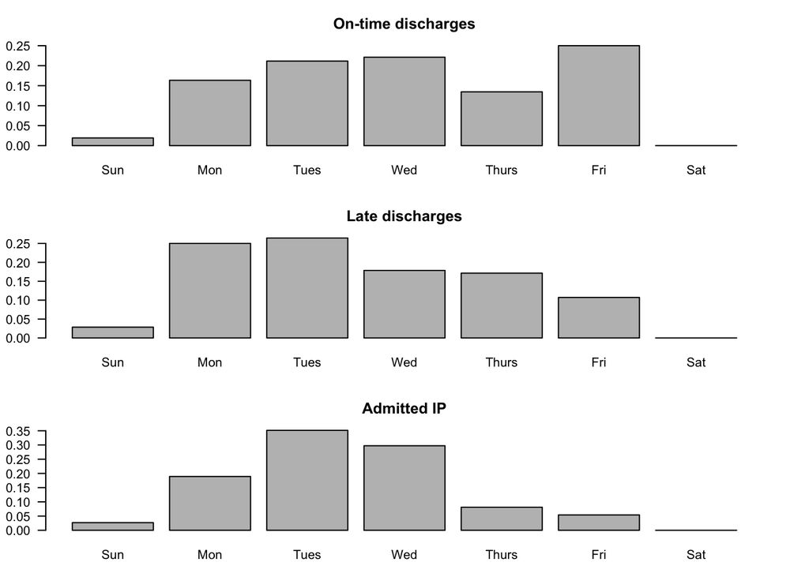

```r
barplot(prop.table(table(days_IP$weekday)))
title(main = "Admitted IP")
```

```r
# Table of late and admitted patients by day of week
day_of_week <- NULL
n_total <- NULL
n_ontime <- NULL
percent_ontime <- NULL
n_late <- NULL
percent_late <- NULL
n_admitedIP <- NULL
percent_IP <- NULL
for(i in 1:length(levels(ORinfo$weekday))){
  day_of_week[i] <- levels(ORinfo$weekday)[i]
  n_total[i] <- nrow(ORinfo[ORinfo$weekday == levels(ORinfo$weekday)[i],])
  n_ontime[i] <- nrow(ORinfo[ORinfo$weekday == levels(ORinfo$weekday)[i] & ORinfo$ERU_outcome == "On_time",])
  percent_ontime[i] <- paste(round(n_ontime[i]/n_total[i]*100, 0), "%")
  n_late[i] <- nrow(ORinfo[ORinfo$weekday == levels(ORinfo$weekday)[i] & ORinfo$ERU_outcome == "Late",])
  percent_late[i] <- paste(round(n_late[i]/n_total[i]*100, 0), "%")
  n_admitedIP[i] <- nrow(ORinfo[ORinfo$weekday == levels(ORinfo$weekday)[i] & ORinfo$ERU_outcome == "IP",])
  percent_IP[i] <- paste(round(n_admitedIP[i]/n_total[i]*100, 0), "%")
}
prop_weekday <- data.frame(day_of_week, n_total, n_ontime, percent_ontime, n_late, percent_late, n_admitedIP, percent_IP)
```

# Service, payor and day of week of OR split by ERU outcomes:

```r
# OR service
arrange(late_prop_service, desc(n_total))
```

```
##    service n_total n_late percent_late n_admitedIP percent_IP
## 1      GYN      60     19         32 %           3        5 %
## 2      URO      42     23         55 %           6       14 %
## 3      PLA      39     20         51 %           1        3 %
## 4      GGI      31     17         55 %           5       16 %
## 5      ORT      19     11         58 %           5       26 %
## 6      OSS      19     13         68 %           3       16 %
## 7      OTO      18      9         50 %           4       22 %
## 8      ANE      16     11         69 %           3       19 %
## 9      OBS      10      5         50 %           0        0 %
## 10     VAS       8      6         75 %           0        0 %
## 11     NSU       7      2         29 %           2       29 %
## 12     ESS       5      3         60 %           1       20 %
## 13     0SS       1      0          0 %           0        0 %
## 14     BMT       1      0          0 %           1      100 %
## 15     BTS       1      0          0 %           0        0 %
## 16     ONC       1      1        100 %           0        0 %
## 17    OTRT       1      0          0 %           1      100 %
## 18     RTR       1      0          0 %           1      100 %
## 19     THO       1      0          0 %           1      100 %
```

```r
# Payer
arrange(late_prop_payer, desc(n_total))
```

```
##            payer n_total n_late percent_late n_admitedIP percent_IP
## 1        UNKNOWN      84     38         45 %          15       18 %
## 2          MCARE      78     42         54 %          12       15 %
## 3     BLUE CROSS      46     22         48 %           4        9 %
## 4            MCD      16      9         56 %           2       12 %
## 5            NHP      16      8         50 %           2       12 %
## 6            THP      13      8         62 %           1        8 %
## 7           HPHC      10      6         60 %           1       10 %
## 8           USHC       4      4        100 %           0        0 %
## 9          CIGNA       3      0          0 %           0        0 %
## 10           COM       2      0          0 %           0        0 %
## 11          HCHP       2      0          0 %           0        0 %
## 12        UNITED       2      1         50 %           0        0 %
## 13         AETNA       1      1        100 %           0        0 %
## 14 INTERNATIONAL       1      1        100 %           0        0 %
## 15          SELF       1      0          0 %           0        0 %
## 16           TMP       1      0          0 %           0        0 %
## 17       UNICARE       1      0          0 %           0        0 %
```

```r
# Day of week of OR
prop_weekday
```

```
##   day_of_week n_total n_ontime percent_ontime n_late percent_late
## 1         Sun       7        2           29 %      4         57 %
## 2         Mon      59       17           29 %     35         59 %
## 3        Tues      72       22           31 %     37         51 %
## 4         Wed      59       23           39 %     25         42 %
## 5       Thurs      41       14           34 %     24         59 %
## 6         Fri      43       26           60 %     15         35 %
## 7         Sat       0        0          NaN %      0        NaN %
##   n_admitedIP percent_IP
## 1           1       14 %
## 2           7       12 %
## 3          13       18 %
## 4          11       19 %
## 5           3        7 %
## 6           2        5 %
## 7           0      NaN %
```

## Types of possibly relevant PACU and ERU events:

```r
# These events have not been tabulated yet

# Types of events that happened in PACU
levels(postop_chron$PACU_event)
```

```
##  [1] "admitted_IP"
##  [2] "anxiety"
##  [3] "aspiration_workup"
##  [4] "BSL_control"
##  [5] "corneal_abrasion"
##  [6] "eye_droop"
##  [7] "HBP"
##  [8] "HBP; hematuria"
##  [9] "HBP; O2saturation"
## [10] "HBP; pain_control"
## [11] "HBP; urinary retention"
## [12] "HBP; voiding_issue"
## [13] "hematuria"
## [14] "LBP"
## [15] "LBP; O2saturation"
```

[output cut: 26 more lines]

```r
# TYpes of Events that happened in ERU
levels(postop_chron$ERU_event)
```

```
##  [1] "admitted_IP"
##  [2] "anxiety"
##  [3] "bleeding; LBP"
##  [4] "breast_swelling"
##  [5] "BSL"
##  [6] "cardiac_issue"
##  [7] "chest_pain"
##  [8] "chest_pain; postop_complication"
##  [9] "chest_pt; iv_med"
## [10] "CPM"
## [11] "CXR_POD1"
## [12] "DDAVP_mane"
## [13] "drain_obs"
## [14] "fever"
## [15] "fever; LBP"
```

[output cut: 50 more lines]

```r
# Types of Multidiciplinary consults on POD1
levels(postop_chron$MDT_consult_POD1)
```

```
##  [1] "admitted_IP"    "cardio_consult" "CW"             "interpreter"
##  [5] "N"              "NULL"           "opthalmology"   "Pharm"
##  [9] "PT"             "PT_admitted_IP" "PT; DMconsult"  "PT; rehab_dc"
## [13] "PT; SW; VNA"    "rehab_dc"       "VNA"
```

## Post-op PACU, ERU and discharge events Timeline:

```r
# For patients who were discharged on time:
chron_ontime
```

```
##                     proportion n_length  n missing_value
## TimeoutOR_after1800   10.68  %      104 11             1
## ERU_after2100         10.58  %      104 11             0
## dc_edu_POD1           26.32  %      104 20            28
## MDplan_after7am       23.91  %      104 22            12
```

```r
# For patients who were discharged late:
chron_late
```

```
##                     proportion n_length  n missing_value
## TimeoutOR_after1800    9.29  %      140 13             0
## ERU_after2100         14.29  %      140 20             0
## dc_edu_POD1           38.68  %      140 41            34
## MDplan_after7am        62.7  %      140 79            14
```

```r
# For patients who were admitted inpatient:
chron_IP
```

```
##                     proportion n_length n missing_value
## TimeoutOR_after1800    8.33  %       37 3             1
## ERU_after2100         16.67  %       37 5             7
```

## Brief glance at the various reasons for late discharges or admission:

```r
# Primary reasons late discharges or admission:
levels(reasons$Prim_reason)
```

```
##  [1] "bleeding"
##  [2] "BSL"
##  [3] "cardiac_issue"
##  [4] "cardio_consult"
##  [5] "case_coordinator ? Review wrong admit status"
##  [6] "corneal_abrasion_postop"
##  [7] "CXR (r/o aspiration)"
##  [8] "dc_edu"
##  [9] "drain_output"
## [10] "failed_PT"
## [11] "fever"
## [12] "foley_edu"
## [13] "hematoma_reop"
## [14] "hematuria"
## [15] "hemodialysis"
```

[output cut: 44 more lines]

```r
# Other reasons late discharges or admission:
levels(reasons$other_reasons)
```

```
##  [1] "background_comorbidities"     "case_coordinator"
##  [3] "dc_edu"                       "drain_edu"
##  [5] "failed_PT"                    "foley_edu"
##  [7] "HBP"                          "healthproxy_dc_edu"
##  [9] "hematuria"                    "iv_med"
## [11] "JP_drain"                     "JP_monitoring"
## [13] "late_TOV"                     "LBP"
## [15] "LBP_hydration"                "low_UO"
## [17] "MD_plan"                      "mobility"
## [19] "O2sats&BSL_overnight"         "O2saturation"
## [21] "opthal_consult"               "OR_postponed"
## [23] "oral_intake"                  "pain_control"
## [25] "patient c/o flushing in face" "pharm_rv"
## [27] "rehab_dc"                     "ride_issue"
## [29] "social_issue"                 "VNA"
## [31] "voiding_issue"                "wound issue"
```

```r
# Create a vector of reasons to create word cloud - giving primary reason twice the weight:

words <- c(as.character(reasons$Prim_reason), as.character(reasons$Prim_reason), as.character(reasons$other_reasons))
themes <- c("bleeding", "BSL", "cardiac_issue", "cardio_consult", "case_coordinator", "corneal_abrasion_postop", "CXR", "dc_edu", "drain", "failed_PT", "fever", "foley_edu", "hematoma", "hematuria", "hemodialysis", "interpreter", "intraop_blood_loss", "unclear", "iv_med", "lab_result", "late_TOV", "low_Ca", "lethargy", "low_UO", "MD_plan", "VNA", "PT", "SW", "med_4_itch", "med_due_8am", "migraine", "mobility", "nausea", "nerve_palsy_postop", "O2sat", "OR_postponed", "oral_intake", "pain_control", "patient_request", "perforation_postop", "refused_dc", "rehab_dc", "returned_OR", "ride_issue", "social_issue", "poor_note", "very_sedated_postop", "voiding_issue", "wound", "background_comorbidities", "BP", "JP_monitoring", "BSL", "opthal_consult", "pharm_rv")
count <- NULL
for (i in 1:length(themes)){
  count[i] <- length(grep(themes[i], words))
}
theme_cloud <- data.frame(cbind(count, themes))
# Export to tab delimited text file
write.table(theme_cloud, "late_theme_cloud.txt", sep="\t", row.names=FALSE, quote=FALSE)
```

## Proportion of ride and last-minute foley issues amongst on_time and late discharges:

```r
# Ride issue is defined as documented waiting for ride as part of reason for being late - hence none of the on time patients have 'ride issue'
# However, last minute foley is any who had a foley placed in the morning of POD1 in order to be discharged on the day

# Amongst on time discharge patients
rf_ontime
```

```
##                   proportion n_length n missing_value
## doc_ride_issue          0  %      104 0             0
## last_minute_foley       0  %      104 0             0
```

```r
# Amongst late discharge patients
rf_late
```

```
##                   proportion n_length  n missing_value
## doc_ride_issue      44.29  %      140 62             0
## last_minute_foley    7.14  %      140 10             0
```

## Indicators of likely poor ERU discharges for On-time and late discharges:

```r
# Patients admitted have been excluded
# Discharge quality indicators are:
# 1. Last minute foley
# 2. Re-admission to Partner's network shown on LMR system within 3 days
# 3. Patient stating 'not ready' for discharge on the 2 day nursing phone follow-up questionnaire

# On time discharges
Q_ontime
```

```
##                            proportion n_length   n missing_value
## last_minute_foley              100  %      104 104             0
## Re.admission.within.3.days  103.06  %      104 101             6
## patient_not_ready4dc        106.35  %      104  67            41
```

```r
# Late discharges
Q_late
```

```
##                            proportion n_length   n missing_value
## last_minute_foley           107.14  %      140 150             0
## Re.admission.within.3.days  105.11  %      140 144             3
## patient_not_ready4dc        118.67  %      140  89            65
```

# Urology patients analysis

```r
eru %>% group_by(service) %>% tally
```

```
## Source: local data frame [19 x 2]
##
##    service     n
##     (fctr) (int)
## 1      0SS     1
## 2      ANE    16
## 3      BMT     1
## 4      BTS     1
## 5      ESS     5
## 6      GGI    31
## 7      GYN    60
## 8      NSU     7
## 9      OBS    10
## 10     ONC     1
## 11     ORT    19
## 12     OSS    19
## 13     OTO    18
## 14    OTRT     1
## 15     PLA    39
## 16     RTR     1
## 17     THO     1
## 18     URO    42
## 19     VAS     8
```

```r
uro <- eru[eru$service == "URO", c("ERU_outcome", "Age", "Gender", "ASA_34", "service","Prim_reason", "other_reasons", "last_minute_foley")]

summary(uro$ERU_outcome)
```

```
## On_time    Late      IP
##      13      23       6
```

```r
prop.table(table(uro$ERU_outcome))
```

```
##
##   On_time      Late        IP
## 0.3095238 0.5476190 0.1428571
```

```r
summary(uro$Age)
```

```
##    Min. 1st Qu.  Median    Mean 3rd Qu.    Max.
##   27.00   64.00   67.00   68.36   75.75   91.00
```

```r
summary(uro$Gender)
```

```
##  F F   M
## 11  0 31
```

```r
summary(uro$ASA_34)
```

```
##    0    1 NULL
##   14   28    0
```

```r
sort(prop.table(table(uro$Prim_reason)), decreasing = TRUE)
```

```
##
##                                   ride_issue
##                                   0.24137931
##                                      MD_plan
##                                   0.13793103
##                                voiding_issue
##                                   0.13793103
##                                    hematuria
##                                   0.10344828
##                                       iv_med
##                                   0.10344828
##                                        fever
##                                   0.06896552
##                                      unclear
##                                   0.06896552
##                                          BSL
##                                   0.03448276
##                              patient_request
##                                   0.03448276
##                                   refused_dc
##                                   0.03448276
##                                          VNA
##                                   0.03448276
##                                     bleeding
##                                   0.00000000
##                                cardiac_issue
##                                   0.00000000
##                               cardio_consult
##                                   0.00000000
## case_coordinator ? Review wrong admit status
##                                   0.00000000
##                      corneal_abrasion_postop
##                                   0.00000000
##                         CXR (r/o aspiration)
##                                   0.00000000
##                                       dc_edu
##                                   0.00000000
##                                 drain_output
##                                   0.00000000
##                                    failed_PT
```

[output cut: 64 more lines]

```
##                                   0.00000000
##                           unclear_poor_notes
##                                   0.00000000
##                          very_sedated_postop
##                                   0.00000000
##                              VNA; ortho_shoe
##                                   0.00000000
##                voiding_issue; foley_edu; VNA
##                                   0.00000000
##                           voiding_issue; VNA
##                                   0.00000000
##                                  wound_issue
##                                   0.00000000
##                                    wound_vac
##                                   0.00000000
```

```r
sort(prop.table(table(uro$other_reasons)), decreasing = TRUE)
```

```
##
##                   ride_issue                    foley_edu
##                   0.38461538                   0.15384615
##                     late_TOV                       dc_edu
##                   0.15384615                   0.07692308
##                    hematuria                     pharm_rv
##                   0.07692308                   0.07692308
##                voiding_issue     background_comorbidities
##                   0.07692308                   0.00000000
##             case_coordinator                    drain_edu
##                   0.00000000                   0.00000000
##                    failed_PT                          HBP
##                   0.00000000                   0.00000000
##           healthproxy_dc_edu                       iv_med
##                   0.00000000                   0.00000000
##                     JP_drain                JP_monitoring
##                   0.00000000                   0.00000000
##                          LBP                LBP_hydration
##                   0.00000000                   0.00000000
##                       low_UO                      MD_plan
##                   0.00000000                   0.00000000
##                     mobility         O2sats&BSL_overnight
##                   0.00000000                   0.00000000
##                 O2saturation               opthal_consult
##                   0.00000000                   0.00000000
##                 OR_postponed                  oral_intake
##                   0.00000000                   0.00000000
##                 pain_control patient c/o flushing in face
##                   0.00000000                   0.00000000
##                     rehab_dc                 social_issue
##                   0.00000000                   0.00000000
##                          VNA                  wound issue
##                   0.00000000                   0.00000000
```

```r
foley_uro <- uro[uro$ERU_outcome != "IP", c("ERU_outcome", "last_minute_foley")]
summary(foley_uro$last_minute_foley)
```

```
##  0  1 IP
## 32  4  0
```

```r
foley_uro
```

```
##     ERU_outcome last_minute_foley
## 43         Late                 0
## 55         Late                 0
## 64         Late                 0
## 65         Late                 1
## 69         Late                 0
## 81         Late                 0
## 92         Late                 0
## 94         Late                 0
## 106        Late                 0
## 113        Late                 0
## 119        Late                 0
## 120        Late                 1
## 126        Late                 0
## 127        Late                 0
```

[output cut: 22 more lines]

# Gynecology patients analysis

```r
eru %>% group_by(service) %>% tally
```

```
## Source: local data frame [19 x 2]
##
##    service     n
##     (fctr) (int)
## 1      0SS     1
## 2      ANE    16
## 3      BMT     1
## 4      BTS     1
## 5      ESS     5
## 6      GGI    31
## 7      GYN    60
## 8      NSU     7
## 9      OBS    10
## 10     ONC     1
## 11     ORT    19
## 12     OSS    19
## 13     OTO    18
## 14    OTRT     1
## 15     PLA    39
## 16     RTR     1
## 17     THO     1
## 18     URO    42
## 19     VAS     8
```

```r
gyne <- eru[eru$service == "GYN", c("ERU_outcome", "Age", "Gender", "ASA_34", "service","Prim_reason", "other_reasons", "last_minute_foley")]

nrow(gyne)
```

```
## [1] 60
```

```r
summary(gyne$ERU_outcome)
```

```
## On_time    Late      IP
##      38      19       3
```

```r
paste(round(prop.table(table(gyne$ERU_outcome))*100,2), "%")
```

```
## [1] "63.33 %" "31.67 %" "5 %"
```

```r
summary(gyne$Age)
```

```
##    Min. 1st Qu.  Median    Mean 3rd Qu.    Max.
##   23.00   43.00   51.50   54.72   67.25   86.00
```

```r
summary(gyne$Gender)
```

```
##  F F   M
## 60  0  0
```

```r
summary(gyne$ASA_34)
```

```
##    0    1 NULL
##   36   23    1
```

```r
sort(prop.table(table(gyne$Prim_reason)), decreasing = TRUE)
```

```
##
##                                   ride_issue
##                                   0.40909091
##                                      unclear
##                                   0.09090909
##                                voiding_issue
##                                   0.09090909
##                      corneal_abrasion_postop
##                                   0.04545455
##                                    foley_edu
##                                   0.04545455
##                           interpreter_dc_edu
##                                   0.04545455
##                           intraop_blood_loss
##                                   0.04545455
##                                   lab_result
##                                   0.04545455
##                                     late_TOV
##                                   0.04545455
##                                       nausea
##                                   0.04545455
##                           nerve_palsy_postop
##                                   0.04545455
##                voiding_issue; foley_edu; VNA
##                                   0.04545455
##                                     bleeding
##                                   0.00000000
##                                          BSL
##                                   0.00000000
##                                cardiac_issue
##                                   0.00000000
##                               cardio_consult
##                                   0.00000000
## case_coordinator ? Review wrong admit status
##                                   0.00000000
##                         CXR (r/o aspiration)
##                                   0.00000000
##                                       dc_edu
##                                   0.00000000
##                                 drain_output
```

[output cut: 64 more lines]

```
##                                   0.00000000
##                           unclear_poor_notes
##                                   0.00000000
##                          very_sedated_postop
##                                   0.00000000
##                                          VNA
##                                   0.00000000
##                              VNA; ortho_shoe
##                                   0.00000000
##                           voiding_issue; VNA
##                                   0.00000000
##                                  wound_issue
##                                   0.00000000
##                                    wound_vac
##                                   0.00000000
```

```r
sort(prop.table(table(gyne$other_reasons)), decreasing = TRUE)
```

```
##
##                   ride_issue                    foley_edu
##                        0.375                        0.125
##                      MD_plan               opthal_consult
##                        0.125                        0.125
##                  oral_intake                voiding_issue
##                        0.125                        0.125
##     background_comorbidities             case_coordinator
##                        0.000                        0.000
##                       dc_edu                    drain_edu
##                        0.000                        0.000
##                    failed_PT                          HBP
##                        0.000                        0.000
##           healthproxy_dc_edu                    hematuria
##                        0.000                        0.000
##                       iv_med                     JP_drain
##                        0.000                        0.000
##                JP_monitoring                     late_TOV
##                        0.000                        0.000
##                          LBP                LBP_hydration
##                        0.000                        0.000
##                       low_UO                     mobility
##                        0.000                        0.000
##         O2sats&BSL_overnight                 O2saturation
##                        0.000                        0.000
##                 OR_postponed                 pain_control
##                        0.000                        0.000
## patient c/o flushing in face                     pharm_rv
##                        0.000                        0.000
##                     rehab_dc                 social_issue
##                        0.000                        0.000
##                          VNA                  wound issue
##                        0.000                        0.000
```

```r
foley_gyn <- gyne[gyne$ERU_outcome != "IP", c("ERU_outcome", "last_minute_foley")]
summary(foley_gyn$last_minute_foley)
```

```
##  0  1 IP
## 55  2  0
```

```r
foley_gyn
```

```
##     ERU_outcome last_minute_foley
## 45         Late                 0
## 48         Late                 0
## 53         Late                 0
## 84         Late                 0
## 85         Late                 0
## 100        Late                 0
## 104        Late                 0
## 111        Late                 0
## 114        Late                 0
## 123        Late                 1
## 142        Late                 0
## 143        Late                 0
## 151        Late                 0
## 156        Late                 0
```

[output cut: 43 more lines]

# Plastic patients analysis

```r
eru %>% group_by(service) %>% tally
```

```
## Source: local data frame [19 x 2]
##
##    service     n
##     (fctr) (int)
## 1      0SS     1
## 2      ANE    16
## 3      BMT     1
## 4      BTS     1
## 5      ESS     5
## 6      GGI    31
## 7      GYN    60
## 8      NSU     7
## 9      OBS    10
## 10     ONC     1
## 11     ORT    19
## 12     OSS    19
## 13     OTO    18
## 14    OTRT     1
## 15     PLA    39
## 16     RTR     1
## 17     THO     1
## 18     URO    42
## 19     VAS     8
```

```r
plas <- eru[eru$service == "PLA", c("ERU_outcome", "Age", "Gender", "ASA_34", "service","Prim_reason", "other_reasons", "last_minute_foley")]

nrow(plas)
```

```
## [1] 39
```

```r
summary(plas$ERU_outcome)
```

```
## On_time    Late      IP
##      18      20       1
```

```r
paste(round(prop.table(table(plas$ERU_outcome))*100,2), "%")
```

```
## [1] "46.15 %" "51.28 %" "2.56 %"
```

```r
summary(plas$Age)
```

```
##    Min. 1st Qu.  Median    Mean 3rd Qu.    Max.
##   21.00   32.00   44.00   43.44   53.00   76.00
```

```r
summary(plas$Gender)
```

```
##  F F   M
## 34  0  5
```

```r
summary(plas$ASA_34)
```

```
##    0    1 NULL
##   29   10    0
```

```r
sort(prop.table(table(plas$Prim_reason)), decreasing = TRUE)
```

```
##
##                                   ride_issue
##                                   0.23809524
##                                      MD_plan
##                                   0.09523810
##                                     rehab_dc
##                                   0.09523810
##                            unclear_poor_note
##                                   0.09523810
## case_coordinator ? Review wrong admit status
##                                   0.04761905
##                                hematoma_reop
##                                   0.04761905
##                           interpreter_dc_edu
##                                   0.04761905
##                                     late_TOV
##                                   0.04761905
##                                   med_4_itch
##                                   0.04761905
##                              nausea_vomiting
##                                   0.04761905
##                                  returned_OR
##                                   0.04761905
##                                      unclear
##                                   0.04761905
##                           unclear_poor_notes
##                                   0.04761905
##                                  wound_issue
##                                   0.04761905
##                                     bleeding
##                                   0.00000000
##                                          BSL
##                                   0.00000000
##                                cardiac_issue
##                                   0.00000000
##                               cardio_consult
##                                   0.00000000
##                      corneal_abrasion_postop
##                                   0.00000000
##                         CXR (r/o aspiration)
```

[output cut: 64 more lines]

```
##                                   0.00000000
##                          very_sedated_postop
##                                   0.00000000
##                                          VNA
##                                   0.00000000
##                              VNA; ortho_shoe
##                                   0.00000000
##                                voiding_issue
##                                   0.00000000
##                voiding_issue; foley_edu; VNA
##                                   0.00000000
##                           voiding_issue; VNA
##                                   0.00000000
##                                    wound_vac
##                                   0.00000000
```

```r
sort(prop.table(table(plas$other_reasons)), decreasing = TRUE)
```

```
##
##                   ride_issue                       dc_edu
##                          0.4                          0.2
##                JP_monitoring                          VNA
##                          0.2                          0.2
##     background_comorbidities             case_coordinator
##                          0.0                          0.0
##                    drain_edu                    failed_PT
##                          0.0                          0.0
##                    foley_edu                          HBP
##                          0.0                          0.0
##           healthproxy_dc_edu                    hematuria
##                          0.0                          0.0
##                       iv_med                     JP_drain
##                          0.0                          0.0
##                     late_TOV                          LBP
##                          0.0                          0.0
##                LBP_hydration                       low_UO
##                          0.0                          0.0
##                      MD_plan                     mobility
##                          0.0                          0.0
##         O2sats&BSL_overnight                 O2saturation
##                          0.0                          0.0
##               opthal_consult                 OR_postponed
##                          0.0                          0.0
##                  oral_intake                 pain_control
##                          0.0                          0.0
## patient c/o flushing in face                     pharm_rv
##                          0.0                          0.0
##                     rehab_dc                 social_issue
##                          0.0                          0.0
##                voiding_issue                  wound issue
##                          0.0                          0.0
```

```r
foley_pla <- plas[plas$ERU_outcome != "IP", c("ERU_outcome", "last_minute_foley")]
summary(foley_pla$last_minute_foley)
```

```
##  0  1 IP
## 38  0  0
```

```r
foley_pla
```

```
##     ERU_outcome last_minute_foley
## 46         Late                 0
## 60         Late                 0
## 62         Late                 0
## 63         Late                 0
## 68         Late                 0
## 73         Late                 0
## 74         Late                 0
## 78         Late                 0
## 82         Late                 0
## 99         Late                 0
## 101        Late                 0
## 108        Late                 0
## 124        Late                 0
## 128        Late                 0
```

[output cut: 24 more lines]

# GGI patients analysis

```r
eru %>% group_by(service) %>% tally
```

```
## Source: local data frame [19 x 2]
##
##    service     n
##     (fctr) (int)
## 1      0SS     1
## 2      ANE    16
## 3      BMT     1
## 4      BTS     1
## 5      ESS     5
## 6      GGI    31
## 7      GYN    60
## 8      NSU     7
## 9      OBS    10
## 10     ONC     1
## 11     ORT    19
## 12     OSS    19
## 13     OTO    18
## 14    OTRT     1
## 15     PLA    39
## 16     RTR     1
## 17     THO     1
## 18     URO    42
## 19     VAS     8
```

```r
ggi <- eru[eru$service == "GGI", c("ERU_outcome", "Age", "Gender", "ASA_34", "service","Prim_reason", "other_reasons", "last_minute_foley")]

nrow(ggi)
```

```
## [1] 31
```

```r
summary(ggi$ERU_outcome)
```

```
## On_time    Late      IP
##       9      17       5
```

```r
paste(round(prop.table(table(ggi$ERU_outcome))*100,2), "%")
```

```
## [1] "29.03 %" "54.84 %" "16.13 %"
```

```r
summary(ggi$Age)
```

```
##    Min. 1st Qu.  Median    Mean 3rd Qu.    Max.
##   30.00   49.00   65.00   60.68   72.00   83.00
```

```r
summary(ggi$Gender)
```

```
##  F F   M
## 20  1 10
```

```r
summary(ggi$ASA_34)
```

```
##    0    1 NULL
##   13   18    0
```

```r
sort(prop.table(table(ggi$Prim_reason)), decreasing = TRUE)
```

```
##
##                                   ride_issue
##                                   0.27272727
##                                      MD_plan
##                                   0.22727273
##                               cardio_consult
##                                   0.04545455
##                                       dc_edu
##                                   0.04545455
##                                        fever
##                                   0.04545455
##                                low_Ca_workup
##                                   0.04545455
##            low_Ca; nausea_vomiting; lethargy
##                                   0.04545455
##                                     migraine
##                                   0.04545455
##                              nausea_vomiting
##                                   0.04545455
##                                 O2saturation
##                                   0.04545455
##                                 pain_control
##                                   0.04545455
##                                          VNA
##                                   0.04545455
##                                voiding_issue
##                                   0.04545455
##                                     bleeding
##                                   0.00000000
##                                          BSL
##                                   0.00000000
##                                cardiac_issue
##                                   0.00000000
## case_coordinator ? Review wrong admit status
##                                   0.00000000
##                      corneal_abrasion_postop
##                                   0.00000000
##                         CXR (r/o aspiration)
##                                   0.00000000
##                                 drain_output
```

[output cut: 64 more lines]

```
##                                   0.00000000
##                           unclear_poor_notes
##                                   0.00000000
##                          very_sedated_postop
##                                   0.00000000
##                              VNA; ortho_shoe
##                                   0.00000000
##                voiding_issue; foley_edu; VNA
##                                   0.00000000
##                           voiding_issue; VNA
##                                   0.00000000
##                                  wound_issue
##                                   0.00000000
##                                    wound_vac
##                                   0.00000000
```

```r
sort(prop.table(table(ggi$other_reasons)), decreasing = TRUE)
```

```
##
##                   ride_issue                 O2saturation
##                   0.35714286                   0.14285714
##             case_coordinator                LBP_hydration
##                   0.07142857                   0.07142857
##                       low_UO                     mobility
##                   0.07142857                   0.07142857
## patient c/o flushing in face                voiding_issue
##                   0.07142857                   0.07142857
##                  wound issue     background_comorbidities
##                   0.07142857                   0.00000000
##                       dc_edu                    drain_edu
##                   0.00000000                   0.00000000
##                    failed_PT                    foley_edu
##                   0.00000000                   0.00000000
##                          HBP           healthproxy_dc_edu
##                   0.00000000                   0.00000000
##                    hematuria                       iv_med
##                   0.00000000                   0.00000000
##                     JP_drain                JP_monitoring
##                   0.00000000                   0.00000000
##                     late_TOV                          LBP
##                   0.00000000                   0.00000000
##                      MD_plan         O2sats&BSL_overnight
##                   0.00000000                   0.00000000
##               opthal_consult                 OR_postponed
##                   0.00000000                   0.00000000
##                  oral_intake                 pain_control
##                   0.00000000                   0.00000000
##                     pharm_rv                     rehab_dc
##                   0.00000000                   0.00000000
##                 social_issue                          VNA
##                   0.00000000                   0.00000000
```

```r
foley_ggi <- ggi[ggi$ERU_outcome != "IP", c("ERU_outcome", "last_minute_foley")]
summary(foley_ggi$last_minute_foley)
```

```
##  0  1 IP
## 26  0  0
```

```r
foley_ggi
```

```
##     ERU_outcome last_minute_foley
## 38         Late                 0
## 41         Late                 0
## 47         Late                 0
## 49         Late                 0
## 57         Late                 0
## 72         Late                 0
## 75         Late                 0
## 107        Late                 0
## 112        Late                 0
## 115        Late                 0
## 116        Late                 0
## 131        Late                 0
## 135        Late                 0
## 136        Late                 0
## 137        Late                 0
## 150        Late                 0
## 161        Late                 0
## 184     On_time                 0
## 190     On_time                 0
## 191     On_time                 0
## 219     On_time                 0
## 220     On_time                 0
## 231     On_time                 0
## 262     On_time                 0
## 265     On_time                 0
## 268     On_time                 0
```

# ANE patients analysis

```r
eru %>% group_by(service) %>% tally
```

```
## Source: local data frame [19 x 2]
##
##    service     n
##     (fctr) (int)
## 1      0SS     1
## 2      ANE    16
## 3      BMT     1
## 4      BTS     1
## 5      ESS     5
## 6      GGI    31
## 7      GYN    60
## 8      NSU     7
## 9      OBS    10
## 10     ONC     1
## 11     ORT    19
## 12     OSS    19
## 13     OTO    18
## 14    OTRT     1
## 15     PLA    39
## 16     RTR     1
## 17     THO     1
## 18     URO    42
## 19     VAS     8
```

```r
ane <- eru[eru$service == "ANE", c("ERU_outcome", "Age", "Gender", "ASA_34", "service","Prim_reason", "other_reasons", "last_minute_foley")]

nrow(ane)
```

```
## [1] 16
```

```r
summary(ane$ERU_outcome)
```

```
## On_time    Late      IP
##       2      11       3
```

```r
paste(round(prop.table(table(ane$ERU_outcome))*100,2), "%")
```

```
## [1] "12.5 %"  "68.75 %" "18.75 %"
```

```r
summary(ane$Age)
```

```
##    Min. 1st Qu.  Median    Mean 3rd Qu.    Max.
##   39.00   47.00   60.50   58.19   68.25   77.00
```

```r
summary(ane$Gender)
```

```
##  F F   M
## 13  0  3
```

```r
summary(ane$ASA_34)
```

```
##    0    1 NULL
##    3   12    1
```

```r
sort(prop.table(table(ane$Prim_reason)), decreasing = TRUE)
```

```
##
##                                      MD_plan
##                                   0.35714286
##                                 pain_control
##                                   0.21428571
##                            unclear_poor_note
##                                   0.14285714
##                                     mobility
##                                   0.07142857
##                                   PT/OT_eval
##                                   0.07142857
##                                 social_issue
##                                   0.07142857
##                           unclear_poor_notes
##                                   0.07142857
##                                     bleeding
##                                   0.00000000
##                                          BSL
##                                   0.00000000
##                                cardiac_issue
##                                   0.00000000
##                               cardio_consult
##                                   0.00000000
## case_coordinator ? Review wrong admit status
##                                   0.00000000
##                      corneal_abrasion_postop
##                                   0.00000000
##                         CXR (r/o aspiration)
##                                   0.00000000
##                                       dc_edu
##                                   0.00000000
##                                 drain_output
##                                   0.00000000
##                                    failed_PT
##                                   0.00000000
##                                        fever
##                                   0.00000000
##                                    foley_edu
##                                   0.00000000
##                                hematoma_reop
```

[output cut: 64 more lines]

```
##                                   0.00000000
##                                          VNA
##                                   0.00000000
##                              VNA; ortho_shoe
##                                   0.00000000
##                                voiding_issue
##                                   0.00000000
##                voiding_issue; foley_edu; VNA
##                                   0.00000000
##                           voiding_issue; VNA
##                                   0.00000000
##                                  wound_issue
##                                   0.00000000
##                                    wound_vac
##                                   0.00000000
```

```r
sort(prop.table(table(ane$other_reasons)), decreasing = TRUE)
```

```
##
##                       dc_edu                      MD_plan
##                    0.1666667                    0.1666667
##                     rehab_dc                   ride_issue
##                    0.1666667                    0.1666667
##                 social_issue                voiding_issue
##                    0.1666667                    0.1666667
##     background_comorbidities             case_coordinator
##                    0.0000000                    0.0000000
##                    drain_edu                    failed_PT
##                    0.0000000                    0.0000000
##                    foley_edu                          HBP
##                    0.0000000                    0.0000000
##           healthproxy_dc_edu                    hematuria
##                    0.0000000                    0.0000000
##                       iv_med                     JP_drain
##                    0.0000000                    0.0000000
##                JP_monitoring                     late_TOV
##                    0.0000000                    0.0000000
##                          LBP                LBP_hydration
##                    0.0000000                    0.0000000
##                       low_UO                     mobility
##                    0.0000000                    0.0000000
##         O2sats&BSL_overnight                 O2saturation
##                    0.0000000                    0.0000000
##               opthal_consult                 OR_postponed
##                    0.0000000                    0.0000000
##                  oral_intake                 pain_control
##                    0.0000000                    0.0000000
## patient c/o flushing in face                     pharm_rv
##                    0.0000000                    0.0000000
##                          VNA                  wound issue
##                    0.0000000                    0.0000000
```

```r
foley_ane <- ane[ane$ERU_outcome != "IP", c("ERU_outcome", "last_minute_foley")]
summary(foley_ane$last_minute_foley)
```

```
##  0  1 IP
## 13  0  0
```

```r
foley_ane
```

```
##     ERU_outcome last_minute_foley
## 51         Late                 0
## 52         Late                 0
## 59         Late                 0
## 97         Late                 0
## 118        Late                 0
## 134        Late                 0
## 146        Late                 0
## 153        Late                 0
## 159        Late                 0
## 173        Late                 0
## 177        Late                 0
## 202     On_time                 0
## 251     On_time                 0
```

# Further work to be done include:

1. Teasing out events in PACU and ERU
2. Teasing out reasons for late discharge and admission
3. Teasing out service and payor info into ERU outcome categories
4. Co-morbidity information still needs cleaning at Excel stage
5. Further exploratory analysis and logistical regression model fitting